# CITS4009_Project_24198573

Jonas LIU

# 1. Introduction

This is an individual project of CITS4009. This project aims to complete exploratory data analytics and predictive modelling for the given data.

# 2. Descriptive Analysis of the Data

This part aims to show some descriptive analysis of the given data.

```
## 'data.frame':    5000 obs. of  13 variables:
##  $ Rank                : int  1 2 3 4 5 6 7 8 9 10 ...
##  $ Release.Group       : chr  "Mission: Impossible II" "Gladiator" "Cast Away" "What Women Want" ...
##  $ X.Worldwide         : num  5.46e+08 4.61e+08 4.30e+08 3.74e+08 3.50e+08 ...
##  $ X.Domestic          : num  2.15e+08 1.88e+08 2.34e+08 1.83e+08 1.38e+08 ...
##  $ Domestic..          : num  39.4 40.8 54.4 48.9 39.4 75.4 50.3 55.6 53.1 53.3 ...
##  $ X.Foreign           : num  3.31e+08 2.73e+08 1.96e+08 1.91e+08 2.12e+08 ...
##  $ Foreign..           : num  60.6 59.2 45.6 51.1 60.6 24.6 49.7 44.4 46.9 46.7 ...
##  $ Year                : int  2000 2000 2000 2000 2000 2000 2000 2000 2000 2000 ...
##  $ Genres              : chr  "Adventure, Action, Thriller" "Action, Drama, Adventure" "Adventure, Drama" "Comedy, Romance" ...
##  $ Rating              : chr  "6.126/10" "8.217/10" "7.663/10" "6.45/10" ...
##  $ Vote_Count          : num  6741 19032 11403 3944 2530 ...
##  $ Original_Language   : chr  "en" "en" "en" "en" ...
##  $ Production_Countries: chr  "United States of America" "United Kingdom, United States of America" "United States of America" "United Kingdom, United States of America" ...
```

```
##       Rank        Release.Group       X.Worldwide          X.Domestic
##  Min.   :  1.00   Length:5000        Min.   :1.666e+06   Min.   :        0
##  1st Qu.: 50.75   Class :character   1st Qu.:2.466e+07   1st Qu.:    92752
##  Median :100.50   Mode  :character   Median :4.845e+07   Median : 17984212
##  Mean   :100.50                      Mean   :1.192e+08   Mean   : 44725233
##  3rd Qu.:150.25                      3rd Qu.:1.198e+08   3rd Qu.: 53868472
##  Max.   :200.00                      Max.   :2.799e+09   Max.   :936662225
##
##    Domestic..       X.Foreign           Foreign..           Year
##  Min.   :  0.00   Min.   :0.000e+00   Min.   :  0.00   Min.   :2000
##  1st Qu.:  0.20   1st Qu.:1.371e+07   1st Qu.: 42.20   1st Qu.:2006
##  Median : 37.05   Median :3.019e+07   Median : 62.95   Median :2012
##  Mean   : 35.74   Mean   :7.449e+07   Mean   : 64.26   Mean   :2012
##  3rd Qu.: 57.80   3rd Qu.:7.212e+07   3rd Qu.: 99.80   3rd Qu.:2018
##  Max.   :100.00   Max.   :1.994e+09   Max.   :100.00   Max.   :2024
##
##     Genres             Rating            Vote_Count      Original_Language
##  Length:5000        Length:5000        Min.   :    0.0   Length:5000
##  Class :character   Class :character   1st Qu.:  205.2   Class :character
##  Mode  :character   Mode  :character   Median : 1035.5   Mode  :character
##                                        Mean   : 2531.6
##                                        3rd Qu.: 3065.0
##                                        Max.   :36753.0
##                                        NA's   :170
##  Production_Countries
##  Length:5000
##  Class :character
##  Mode  :character
##
##
##
##
```

```
##    Rank                  Release.Group X.Worldwide X.Domestic Domestic..
## 1     1         Mission: Impossible II   546388108  215409889       39.4
## 2     2                      Gladiator   460583960  187705427       40.8
## 3     3                      Cast Away   429632142  233632142       54.4
## 4     4                What Women Want   374111707  182811707       48.9
## 5     5                       Dinosaur   349822765  137748063       39.4
## 6     6 How the Grinch Stole Christmas   345842198  260745620       75.4
## 7     7               Meet the Parents   330444045  166244045       50.3
## 8     8              The Perfect Storm   328718434  182618434       55.6
## 9     9                          X-Men   296339528  157299718       53.1
## 10   10              What Lies Beneath   291420351  155464351       53.3
##    X.Foreign Foreign.. Year                             Genres   Rating
## 1  330978219      60.6 2000        Adventure, Action, Thriller 6.126/10
## 2  272878533      59.2 2000           Action, Drama, Adventure 8.217/10
## 3  196000000      45.6 2000                   Adventure, Drama 7.663/10
```

[output cut: 18 more lines]

Overall, there are 5000 observations with 13 variables. The minimum values of variable X.Domestic and X.Foreign are both 0, which is unusual.Moreover, the maximum values of the two variables are significantly higher than other records. The values of X.Foreign is generally higher than the values of X.Domestic. Since Genres, Rating, Original_Language, and Production_Countries are stored as character variables rather than factors, the summary() function does not display category counts. In addition, there are 170 missing values in variable Vote_Count.

```
## 'data.frame':    266 obs. of  29 variables:
##  $ Country.Name  : chr  "Aruba" "Africa Eastern and Southern" "Afghanistan" "Africa Western and Central" ...
##  $ Country.Code  : chr  "ABW" "AFE" "AFG" "AFW" ...
##  $ Indicator.Name: chr  "GDP (current US$)" "GDP (current US$)" "GDP (current US$)" "GDP (current US$)" ...
##  $ Indicator.Code: chr  "NY.GDP.MKTP.CD" "NY.GDP.MKTP.CD" "NY.GDP.MKTP.CD" "NY.GDP.MKTP.CD" ...
##  $ X2000         : num  1.87e+09 2.87e+11 3.52e+09 1.42e+11 9.13e+09 ...
##  $ X2001         : num  1.90e+09 2.61e+11 2.81e+09 1.50e+11 8.94e+09 ...
##  $ X2002         : num  1.96e+09 2.68e+11 3.83e+09 1.79e+11 1.53e+10 ...
##  $ X2003         : num  2.04e+09 3.56e+11 4.52e+09 2.08e+11 1.78e+10 ...
##  $ X2004         : num  2.25e+09 4.43e+11 5.22e+09 2.59e+11 2.36e+10 ...
##  $ X2005         : num  2.36e+09 5.17e+11 6.20e+09 3.17e+11 3.70e+10 ...
##  $ X2006         : num  2.47e+09 5.80e+11 6.97e+09 4.03e+11 5.24e+10 ...
##  $ X2007         : num  2.68e+09 6.66e+11 9.75e+09 4.72e+11 6.53e+10 ...
##  $ X2008         : num  2.84e+09 7.14e+11 1.01e+10 5.75e+11 8.85e+10 ...
##  $ X2009         : num  2.55e+09 7.15e+11 1.24e+10 5.15e+11 7.03e+10 ...
##  $ X2010         : num  2.45e+09 8.49e+11 1.59e+10 6.06e+11 8.38e+10 ...
##  $ X2011         : num  2.64e+09 9.45e+11 1.78e+10 6.91e+11 1.12e+11 ...
##  $ X2012         : num  2.62e+09 9.53e+11 1.99e+10 7.48e+11 1.28e+11 ...
##  $ X2013         : num  2.73e+09 9.62e+11 2.01e+10 8.44e+11 1.32e+11 ...
##  $ X2014         : num  2.79e+09 9.79e+11 2.05e+10 9.04e+11 1.36e+11 ...
##  $ X2015         : num  2.96e+09 8.98e+11 1.91e+10 7.78e+11 9.05e+10 ...
##  $ X2016         : num  2.98e+09 8.29e+11 1.81e+10 7.00e+11 5.28e+10 ...
##  $ X2017         : num  3.09e+09 9.73e+11 1.88e+10 6.94e+11 7.37e+10 ...
##  $ X2018         : num  3.28e+09 1.01e+12 1.81e+10 7.78e+11 7.95e+10 ...
##  $ X2019         : num  3.40e+09 1.01e+12 1.88e+10 8.33e+11 7.09e+10 ...
##  $ X2020         : num  2.48e+09 9.33e+11 2.00e+10 7.97e+11 4.85e+10 ...
##  $ X2021         : num  2.93e+09 1.09e+12 1.43e+10 8.58e+11 6.65e+10 ...
##  $ X2022         : num  3.28e+09 1.19e+12 1.45e+10 8.94e+11 1.04e+11 ...
##  $ X2023         : num  3.65e+09 1.18e+12 1.72e+10 8.15e+11 8.49e+10 ...
##  $ X2024         : num  NA 1.29e+12 NA 6.70e+11 8.04e+10 ...
```

```
##  Country.Name       Country.Code       Indicator.Name     Indicator.Code
##  Length:266         Length:266         Length:266         Length:266
##  Class :character   Class :character   Class :character   Class :character
##  Mode  :character   Mode  :character   Mode  :character   Mode  :character
##
##
##
##
##      X2000               X2001               X2002
##  Min.   :1.507e+07   Min.   :1.396e+07   Min.   :1.684e+07
##  1st Qu.:3.035e+09   1st Qu.:2.814e+09   1st Qu.:3.034e+09
##  Median :1.439e+10   Median :1.418e+10   Median :1.459e+10
##  Mean   :9.869e+11   Mean   :9.800e+11   Mean   :1.003e+12
##  3rd Qu.:1.912e+11   3rd Qu.:1.918e+11   3rd Qu.:1.957e+11
##  Max.   :3.387e+13   Max.   :3.366e+13   Max.   :3.496e+13
##  NA's   :14          NA's   :13          NA's   :9
##      X2003               X2004               X2005
##  Min.   :1.946e+07   Min.   :2.280e+07   Min.   :2.291e+07
##  1st Qu.:3.504e+09   1st Qu.:4.044e+09   1st Qu.:4.866e+09
##  Median :1.781e+10   Median :2.066e+10   Median :2.150e+10
##  Mean   :1.132e+12   Mean   :1.285e+12   Mean   :1.406e+12
##  3rd Qu.:2.186e+11   3rd Qu.:2.586e+11   3rd Qu.:3.100e+11
##  Max.   :3.921e+13   Max.   :4.418e+13   Max.   :4.785e+13
##  NA's   :9           NA's   :9           NA's   :9
##      X2006               X2007               X2008
##  Min.   :2.410e+07   Min.   :2.307e+07   Min.   :3.187e+07
##  1st Qu.:5.107e+09   1st Qu.:5.831e+09   1st Qu.:6.603e+09
##  Median :2.400e+10   Median :3.069e+10   Median :3.414e+10
##  Mean   :1.537e+12   Mean   :1.759e+12   Mean   :1.955e+12
##  3rd Qu.:3.467e+11   3rd Qu.:4.128e+11   3rd Qu.:4.949e+11
##  Max.   :5.186e+13   Max.   :5.845e+13   Max.   :6.423e+13
##  NA's   :8           NA's   :8           NA's   :7
##      X2009               X2010               X2011
##  Min.   :2.808e+07   Min.   :3.211e+07   Min.   :3.920e+07
##  1st Qu.:6.043e+09   1st Qu.:6.853e+09   1st Qu.:7.102e+09
##  Median :3.540e+10   Median :4.068e+10   Median :4.503e+10
##  Mean   :1.846e+12   Mean   :2.048e+12   Mean   :2.292e+12
##  3rd Qu.:4.291e+11   3rd Qu.:4.816e+11   3rd Qu.:5.296e+11
##  Max.   :6.091e+13   Max.   :6.672e+13   Max.   :7.421e+13
##  NA's   :5           NA's   :5           NA's   :4
```

[output cut: 25 more lines]

```
##  Min.   :6.020e+07   Min.   :5.907e+07   Min.   :6.228e+07
##  1st Qu.:1.007e+10   1st Qu.:1.236e+10   1st Qu.:1.516e+10
##  Median :6.196e+10   Median :6.992e+10   Median :7.954e+10
##  Mean   :3.160e+12   Mean   :3.306e+12   Mean   :3.558e+12
##  3rd Qu.:6.372e+11   3rd Qu.:6.485e+11   3rd Qu.:8.347e+11
##  Max.   :9.837e+13   Max.   :1.024e+14   Max.   :1.070e+14
##  NA's   :9           NA's   :10          NA's   :18
##      X2024
##  Min.   :1.604e+08
##  1st Qu.:1.947e+10
##  Median :9.320e+10
##  Mean   :3.965e+12
##  3rd Qu.:1.213e+12
##  Max.   :1.113e+14
##  NA's   :35
```

```
##                   Country.Name Country.Code    Indicator.Name Indicator.Code
## 1                        Aruba          ABW GDP (current US$) NY.GDP.MKTP.CD
## 2  Africa Eastern and Southern          AFE GDP (current US$) NY.GDP.MKTP.CD
## 3                  Afghanistan          AFG GDP (current US$) NY.GDP.MKTP.CD
## 4   Africa Western and Central          AFW GDP (current US$) NY.GDP.MKTP.CD
## 5                       Angola          AGO GDP (current US$) NY.GDP.MKTP.CD
## 6                      Albania          ALB GDP (current US$) NY.GDP.MKTP.CD
## 7                      Andorra          AND GDP (current US$) NY.GDP.MKTP.CD
## 8                   Arab World          ARB GDP (current US$) NY.GDP.MKTP.CD
## 9         United Arab Emirates          ARE GDP (current US$) NY.GDP.MKTP.CD
## 10                   Argentina          ARG GDP (current US$) NY.GDP.MKTP.CD
##           X2000        X2001        X2002        X2003        X2004
## 1    1873452514   1896456983   1961843575   2044111732   2254830726
## 2  287202000000 260992000000 267815000000 355716000000 442696000000
## 3    3521418060   2813571754   3825701439   4520946819   5224896719
```

[output cut: 51 more lines]

In summary, the GDP dataset contains 266 observations with 29 variables, including country information and yearly GDP values from 2000 to 2024. The variables Country.Name, Country.Code, Indicator.Name and Indicator.Code are all stored as character. Each year contains around 10 missing values while 2024 has the most missing values, with 35. There is also a general upward trend in global GDP over time.

```
## 'data.frame':    5700 obs. of  16 variables:
##  $ Name                                : chr  " -> 2000" "Afghanistan" "Albania" "Algeria" ...
##  $ GENC                                : chr  "" "AF" "AL" "DZ" ...
##  $ Year                                : int  NA 2000 2000 2000 2000 2000 2000 2000 2000 2000 ...
##  $ Population                          : chr  "--" "23,603,559" "3,158,350" "30,634,947" ...
##  $ Male.Population                     : chr  "--" "12,024,477" "1,588,136" "15,479,993" ...
##  $ Female.Population                   : chr  "--" "11,579,082" "1,570,214" "15,154,954" ...
##  $ Annual.Growth.Rate                  : chr  "--" "-0.79" "-1.02" "1.4" ...
##  $ Rate.of.Natural.Increase            : chr  "--" "3.52" "1.1" "1.46" ...
##  $ Population.Density                  : chr  "--" "36.2" "115.3" "12.9" ...
##  $ Natural.Increase                    : chr  "--" "831,205" "34,849" "446,991" ...
##  $ Total.Fertility.Rate                : chr  "--" "7.4" "2.17" "2.37" ...
##  $ Crude.Birth.Rate                    : chr  "--" "46.7" "16.4" "19.2" ...
##  $ Life.Expectancy.at.Birth..Both.Sexes: chr  "--" "56.4" "74.7" "71.8" ...
##  $ Infant.Mortality.Rate..Both.Sexes   : chr  "--" "87.6" "22.6" "38.5" ...
##  $ Crude.Death.Rate                    : chr  "--" "11.5" "5.4" "4.6" ...
##  $ Net.Migration.Rate                  : chr  "--" "-43.1" "-21.2" "-0.6" ...
```

```
##      Name               GENC                Year       Population
##  Length:5700        Length:5700        Min.   :2000   Length:5700
##  Class :character   Class :character   1st Qu.:2006   Class :character
##  Mode  :character   Mode  :character   Median :2012   Mode  :character
##                                        Mean   :2012
##                                        3rd Qu.:2018
##                                        Max.   :2024
##                                        NA's   :25
##  Male.Population    Female.Population  Annual.Growth.Rate
##  Length:5700        Length:5700        Length:5700
##  Class :character   Class :character   Class :character
##  Mode  :character   Mode  :character   Mode  :character
##
##
##
##
##  Rate.of.Natural.Increase Population.Density Natural.Increase
##  Length:5700              Length:5700        Length:5700
##  Class :character         Class :character   Class :character
##  Mode  :character         Mode  :character   Mode  :character
##
##
##
##
##  Total.Fertility.Rate Crude.Birth.Rate   Life.Expectancy.at.Birth..Both.Sexes
##  Length:5700          Length:5700        Length:5700
##  Class :character     Class :character   Class :character
##  Mode  :character     Mode  :character   Mode  :character
##
##
##
##
##  Infant.Mortality.Rate..Both.Sexes Crude.Death.Rate   Net.Migration.Rate
##  Length:5700                       Length:5700        Length:5700
##  Class :character                  Class :character   Class :character
##  Mode  :character                  Mode  :character   Mode  :character
##
##
##
##
```

```
##                   Name GENC Year Population Male.Population Female.Population
## 1              -> 2000        NA         --              --                --
## 2          Afghanistan   AF 2000 23,603,559      12,024,477        11,579,082
## 3              Albania   AL 2000  3,158,350       1,588,136         1,570,214
## 4              Algeria   DZ 2000 30,634,947      15,479,993        15,154,954
## 5       American Samoa   AS 2000     57,699          29,389            28,310
## 6              Andorra   AD 2000     65,099          34,013            31,086
## 7               Angola   AO 2000 14,550,196       7,200,546         7,349,650
## 8             Anguilla   AI 2000     11,426           5,701             5,725
## 9  Antigua and Barbuda   AG 2000     75,352          36,073            39,279
## 10           Argentina   AR 2000 37,335,675      18,417,748        18,917,927
##    Annual.Growth.Rate Rate.of.Natural.Increase Population.Density
## 1                  --                       --                 --
## 2               -0.79                     3.52               36.2
## 3               -1.02                      1.1              115.3
```

[output cut: 40 more lines]

Given that almost all variables are stored as character strings rather than numeric values, the summary() function can’t give any useful information. In the meantime, head() shows that this is due to the use of formatting symbols such as commas and placeholder entries like “–”, which prevent direct numeric interpretation. This problem will be addressed in Data Cleaning and Transformation part.

# 3. Visualisation

This part visualizes the three datasets to explore the potential information by using different types of plots and charts.

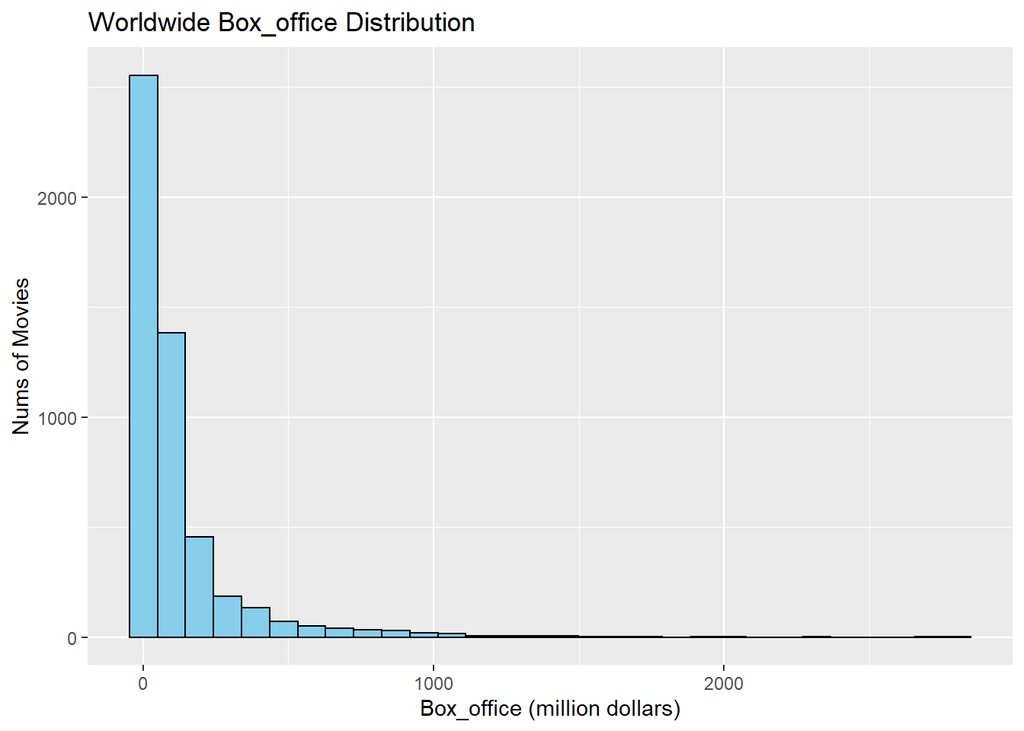

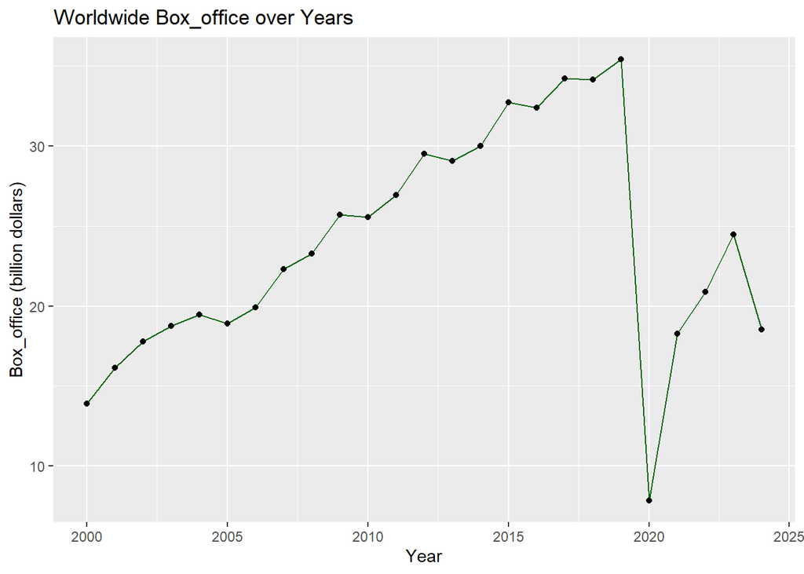

Worldwide Box Office Distribution: There is a highly skewed distribution with a long right tail in the histogram.The majority of movies earn relatively low worldwide box office revenues, concentrated under a few hundred million dollars. Only a small number of movies exceed the one-billion-dollar mark. This suggests that while popular movies dominate total revenue, most films achieve only modest earnings.

Box Office Trend over Years: From 2000 to around 2019, global box office revenue shows a clear upward trend, reflecting the overall growth of the film industry and international market expansion. But there is a sharp slump from 2019 to 2020 with the impact of the COVID-19 pandemic, which severely reduced cinema attendance and box office income. After 2020, there is a noticeable recovery. However, there comes a abrupt decline again in 2024.

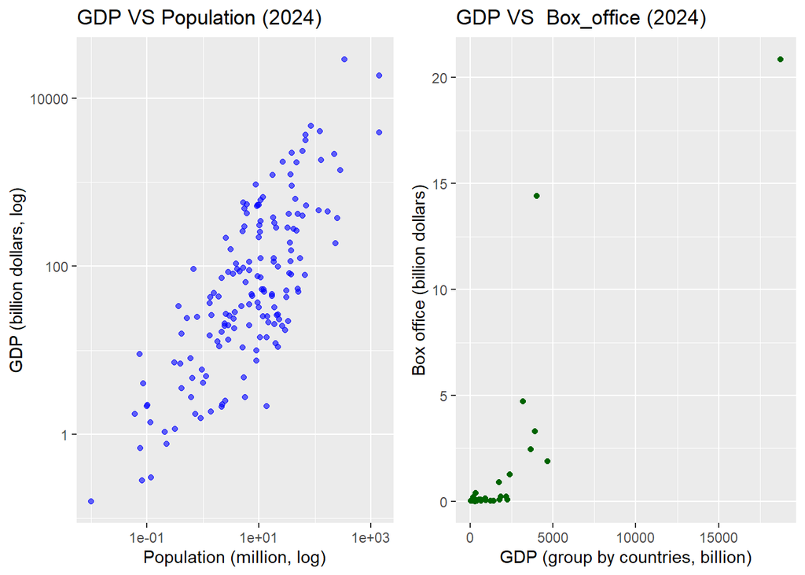

GDP vs Population (2024): In the scatter plot, a log–log scale is applied to reduce skewness and better visualise the wide range of values.The plot shows a clear positive correlation between population size and GDP. Countries with larger populations tend to have higher GDP, although the relationship is not totally linear since some small-population countries achieve relatively high GDP. Additionally, there is also a clustered pattern: most countries fall into the lower-middle range, while only a few lie on the upper-right corner and the lower-left corner.

GDP vs Box Office (2024, by Production Country): A general upward trend is observed: countries with higher GDP also tend to contribute more to global box office revenues. However, the distribution is highly concentrated in the lower-left corner, with only a few countries generating the majority of box office income.

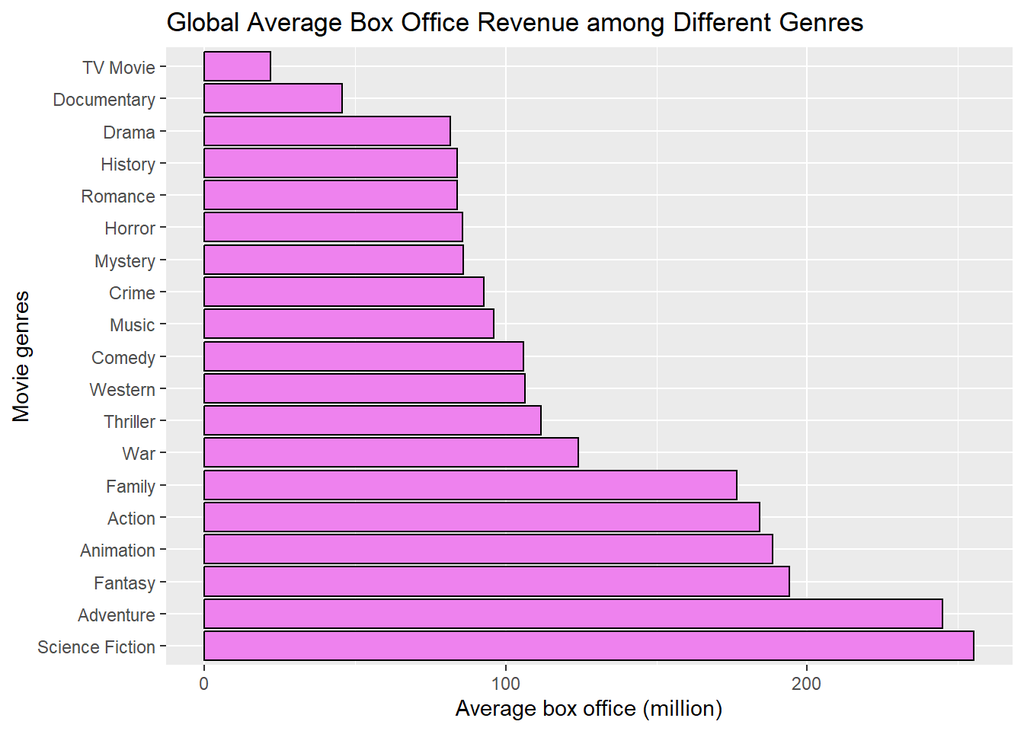

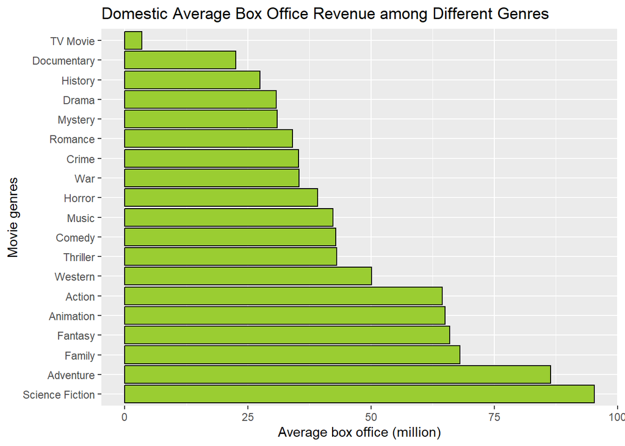

Global Trends:  
At the global level, genres such as Science Fiction, Adventure, and Fantasy, demonstrate their dominance in generating box office revenues. In contrast, genres like Documentary, TV Movie, and Drama, are not so popular with the lowest revenues.

Domestic Trends: A similar pattern is observed domestically, though the overall revenue levels are significantly smaller compared to the global scale. Science Fiction, Adventure, and Family films perform the best, while TV Movie are extremely low-profit.

Comparison: What’s interesting is that certain genres such as Western, Family, and Horror appear relatively stronger in domestic markets compared to their global averages. In contrast, the popularity of war movies has a obvious decline in domestic markets.

# 4. Data Cleaning and Transformation

Based on the former steps, there are some identified problems in the datasets. This part concentrates on cleaning data and transforming data into a more practicable format.

## 4.1 Missing Values Preview

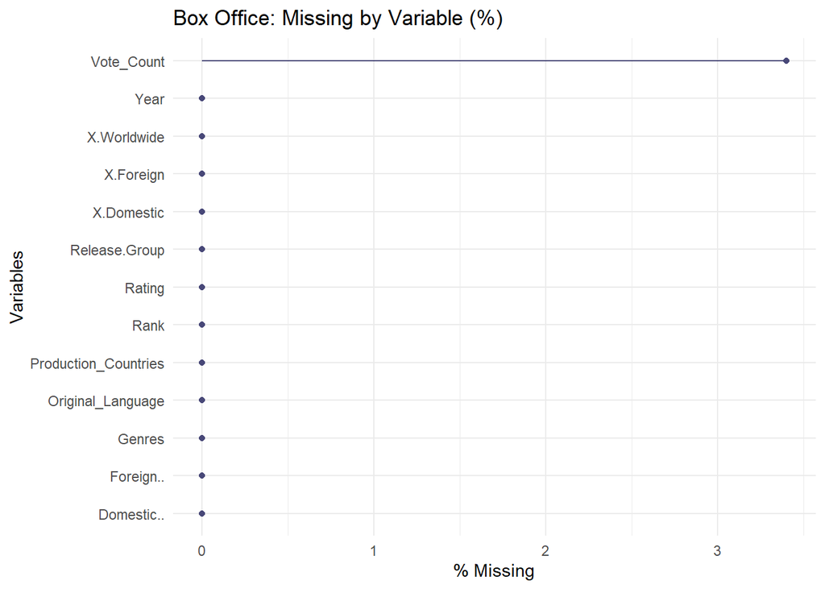

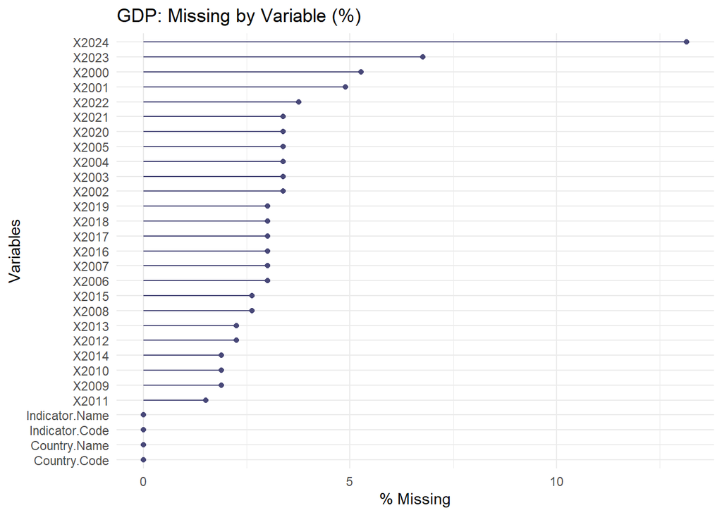

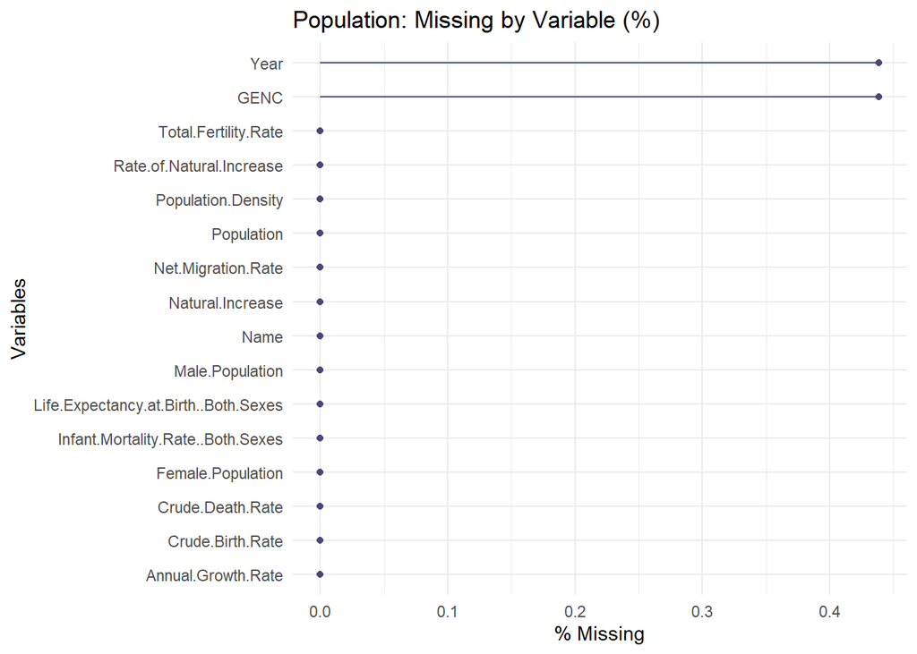

Box_Office: Only the Vote_Count variable shows missing values (~3%), while all other variables are nearly complete.

Population: Almost all variables are complete (<0.5% missing).

## 4.2 Data Transformation

According to former parts, some values in tables have incorrect format. The first thing is to filter some rows with invalid key columns, and replace “–/NA/null” with NA. Then the numbers in the character variables are converted to actual numerical values. Additionally, some columns like country name and country code have been standardized in order to match with other table.

Besides, there is a new aggregation box office table based on country_code and year. A long table is generated for gdp.

```
## 'data.frame':    5000 obs. of  14 variables:
##  $ Rank                : int  1 2 3 4 5 6 7 8 9 10 ...
##  $ Release.Group       : chr  "Mission: Impossible II" "Gladiator" "Cast Away" "What Women Want" ...
##  $ X.Worldwide         : num  5.46e+08 4.61e+08 4.30e+08 3.74e+08 3.50e+08 ...
##  $ X.Domestic          : num  2.15e+08 1.88e+08 2.34e+08 1.83e+08 1.38e+08 ...
##  $ Domestic..          : num  39.4 40.8 54.4 48.9 39.4 75.4 50.3 55.6 53.1 53.3 ...
##  $ X.Foreign           : num  3.31e+08 2.73e+08 1.96e+08 1.91e+08 2.12e+08 ...
##  $ Foreign..           : num  60.6 59.2 45.6 51.1 60.6 24.6 49.7 44.4 46.9 46.7 ...
##  $ Year                : int  2000 2000 2000 2000 2000 2000 2000 2000 2000 2000 ...
##  $ Genres              : chr  "Adventure, Action, Thriller" "Action, Drama, Adventure" "Adventure, Drama" "Comedy, Romance" ...
##  $ Rating              : chr  "6.126/10" "8.217/10" "7.663/10" "6.45/10" ...
##  $ Vote_Count          : num  6741 19032 11403 3944 2530 ...
##  $ Original_Language   : chr  "en" "en" "en" "en" ...
##  $ Production_Countries: chr  "United States of America" "United Kingdom, United States of America" "United States of America" "United Kingdom, United States of America" ...
##  $ Rating_num          : num  6.13 8.22 7.66 6.45 6.54 ...
```

```
## # A tibble: 10 × 6
##    Country_Code  Year n_films worldwide_usd_sum domestic_usd_sum domestic_share
##    <chr>        <int>   <int>             <dbl>            <dbl>          <dbl>
##  1 ARE           2009       1          28972508         20919166         0.722
##  2 ARE           2010       4         147123299         55384910         0.376
##  3 ARE           2011       2         353154979        245366209         0.695
##  4 ARE           2012       2         269400086         98186043         0.364
##  5 ARE           2013       1          57824674         42930462         0.742
##  6 ARE           2014       1          89078609         54240821         0.609
##  7 ARE           2017       3         524273643         62049989         0.118
##  8 ARE           2023       1           9387311          4813132         0.513
##  9 ARE           2024       1          15469415         10001000         0.647
## 10 ARG           2001       1           8772695           624757         0.0712
```

```
## 'data.frame':    5675 obs. of  16 variables:
##  $ Country_Name                        : chr  "Afghanistan" "Albania" "Algeria" "American Samoa" ...
##  $ Country_Code                        : chr  "AFG" "ALB" "DZA" "ASM" ...
##  $ Year                                : int  2000 2000 2000 2000 2000 2000 2000 2000 2000 2000 ...
##  $ Population                          : num  23603559 3158350 30634947 57699 65099 ...
##  $ Male.Population                     : num  12024477 1588136 15479993 29389 34013 ...
##  $ Female.Population                   : num  11579082 1570214 15154954 28310 31086 ...
##  $ Annual.Growth.Rate                  : num  -0.79 -1.02 1.4 0.09 -0.12 2.43 3.09 1.97 1.12 -0.24 ...
##  $ Rate.of.Natural.Increase            : num  3.52 1.1 1.46 2.65 0.61 3.02 1.09 1.7 1.17 0.64 ...
##  $ Population.Density                  : num  36.2 115.3 12.9 291.4 139.1 ...
##  $ Natural.Increase                    : num  831205 34849 446991 1528 398 ...
##  $ Total.Fertility.Rate                : num  7.4 2.17 2.37 4 1.37 6.73 2.11 2.72 2.57 1.81 ...
##  $ Crude.Birth.Rate                    : num  46.7 16.4 19.2 30 11.5 47.9 16.9 23.5 19.3 14.2 ...
##  $ Life.Expectancy.at.Birth..Both.Sexes: num  56.4 74.7 71.8 74.9 81 47.1 76.6 73.5 74.4 71.6 ...
##  $ Infant.Mortality.Rate..Both.Sexes   : num  87.6 22.6 38.5 10.6 4.9 ...
##  $ Crude.Death.Rate                    : num  11.5 5.4 4.6 3.5 5.4 17.7 6 6.5 7.6 7.9 ...
##  $ Net.Migration.Rate                  : num  -43.1 -21.2 -0.6 -25.6 -7.3 -5.9 20 2.7 -0.4 -8.8 ...
```

```
##           Country_Name Country_Code Year Population Male.Population
## 1          Afghanistan          AFG 2000   23603559        12024477
## 2              Albania          ALB 2000    3158350         1588136
## 3              Algeria          DZA 2000   30634947        15479993
## 4       American Samoa          ASM 2000      57699           29389
## 5              Andorra          AND 2000      65099           34013
## 6               Angola          AGO 2000   14550196         7200546
## 7             Anguilla          AIA 2000      11426            5701
## 8  Antigua and Barbuda          ATG 2000      75352           36073
## 9            Argentina          ARG 2000   37335675        18417748
## 10             Armenia          ARM 2000    3100044         1462333
##    Female.Population Annual.Growth.Rate Rate.of.Natural.Increase
## 1           11579082              -0.79                     3.52
## 2            1570214              -1.02                     1.10
## 3           15154954               1.40                     1.46
```

[output cut: 40 more lines]

```
## 'data.frame':    266 obs. of  29 variables:
##  $ Country_Name  : chr  "Aruba" "Africa Eastern and Southern" "Afghanistan" "Africa Western and Central" ...
##  $ Country_Code  : chr  "ABW" "AFE" "AFG" "AFW" ...
##  $ Indicator.Name: chr  "GDP (current US$)" "GDP (current US$)" "GDP (current US$)" "GDP (current US$)" ...
##  $ Indicator.Code: chr  "NY.GDP.MKTP.CD" "NY.GDP.MKTP.CD" "NY.GDP.MKTP.CD" "NY.GDP.MKTP.CD" ...
##  $ 2000          : num  1.87e+09 2.87e+11 3.52e+09 1.42e+11 9.13e+09 ...
##  $ 2001          : num  1.90e+09 2.61e+11 2.81e+09 1.50e+11 8.94e+09 ...
##  $ 2002          : num  1.96e+09 2.68e+11 3.83e+09 1.79e+11 1.53e+10 ...
##  $ 2003          : num  2.04e+09 3.56e+11 4.52e+09 2.08e+11 1.78e+10 ...
##  $ 2004          : num  2.25e+09 4.43e+11 5.22e+09 2.59e+11 2.36e+10 ...
##  $ 2005          : num  2.36e+09 5.17e+11 6.20e+09 3.17e+11 3.70e+10 ...
##  $ 2006          : num  2.47e+09 5.80e+11 6.97e+09 4.03e+11 5.24e+10 ...
##  $ 2007          : num  2.68e+09 6.66e+11 9.75e+09 4.72e+11 6.53e+10 ...
##  $ 2008          : num  2.84e+09 7.14e+11 1.01e+10 5.75e+11 8.85e+10 ...
##  $ 2009          : num  2.55e+09 7.15e+11 1.24e+10 5.15e+11 7.03e+10 ...
##  $ 2010          : num  2.45e+09 8.49e+11 1.59e+10 6.06e+11 8.38e+10 ...
##  $ 2011          : num  2.64e+09 9.45e+11 1.78e+10 6.91e+11 1.12e+11 ...
##  $ 2012          : num  2.62e+09 9.53e+11 1.99e+10 7.48e+11 1.28e+11 ...
##  $ 2013          : num  2.73e+09 9.62e+11 2.01e+10 8.44e+11 1.32e+11 ...
##  $ 2014          : num  2.79e+09 9.79e+11 2.05e+10 9.04e+11 1.36e+11 ...
##  $ 2015          : num  2.96e+09 8.98e+11 1.91e+10 7.78e+11 9.05e+10 ...
##  $ 2016          : num  2.98e+09 8.29e+11 1.81e+10 7.00e+11 5.28e+10 ...
##  $ 2017          : num  3.09e+09 9.73e+11 1.88e+10 6.94e+11 7.37e+10 ...
##  $ 2018          : num  3.28e+09 1.01e+12 1.81e+10 7.78e+11 7.95e+10 ...
##  $ 2019          : num  3.40e+09 1.01e+12 1.88e+10 8.33e+11 7.09e+10 ...
##  $ 2020          : num  2.48e+09 9.33e+11 2.00e+10 7.97e+11 4.85e+10 ...
##  $ 2021          : num  2.93e+09 1.09e+12 1.43e+10 8.58e+11 6.65e+10 ...
##  $ 2022          : num  3.28e+09 1.19e+12 1.45e+10 8.94e+11 1.04e+11 ...
##  $ 2023          : num  3.65e+09 1.18e+12 1.72e+10 8.15e+11 8.49e+10 ...
##  $ 2024          : num  NA 1.29e+12 NA 6.70e+11 8.04e+10 ...
```

```
## # A tibble: 10 × 6
##    Country_Name Country_Code Indicator.Name    Indicator.Code  Year    gdp_usd
##    <chr>        <chr>        <chr>             <chr>          <int>      <dbl>
##  1 Aruba        ABW          GDP (current US$) NY.GDP.MKTP.CD  2000 1873452514
##  2 Aruba        ABW          GDP (current US$) NY.GDP.MKTP.CD  2001 1896456983
##  3 Aruba        ABW          GDP (current US$) NY.GDP.MKTP.CD  2002 1961843575
##  4 Aruba        ABW          GDP (current US$) NY.GDP.MKTP.CD  2003 2044111732
##  5 Aruba        ABW          GDP (current US$) NY.GDP.MKTP.CD  2004 2254830726
##  6 Aruba        ABW          GDP (current US$) NY.GDP.MKTP.CD  2005 2360017318
##  7 Aruba        ABW          GDP (current US$) NY.GDP.MKTP.CD  2006 2469782682
##  8 Aruba        ABW          GDP (current US$) NY.GDP.MKTP.CD  2007 2677641341
##  9 Aruba        ABW          GDP (current US$) NY.GDP.MKTP.CD  2008 2843024581
## 10 Aruba        ABW          GDP (current US$) NY.GDP.MKTP.CD  2009 2553793296
```

## 4.3 Missing Values Operation

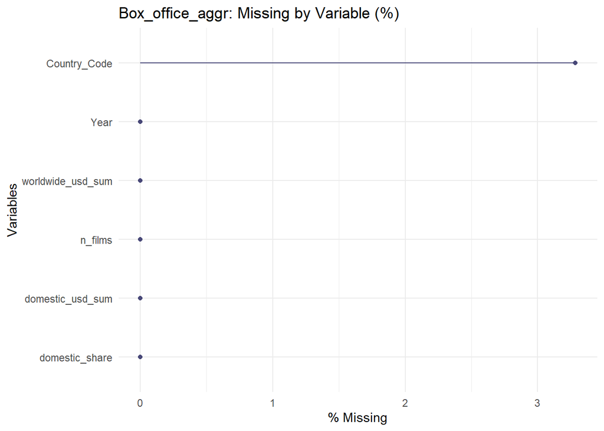

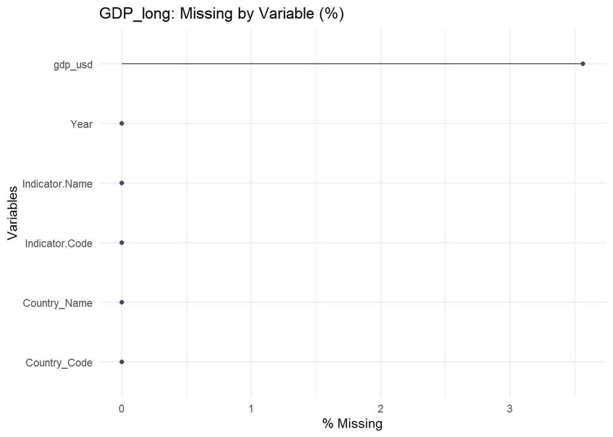

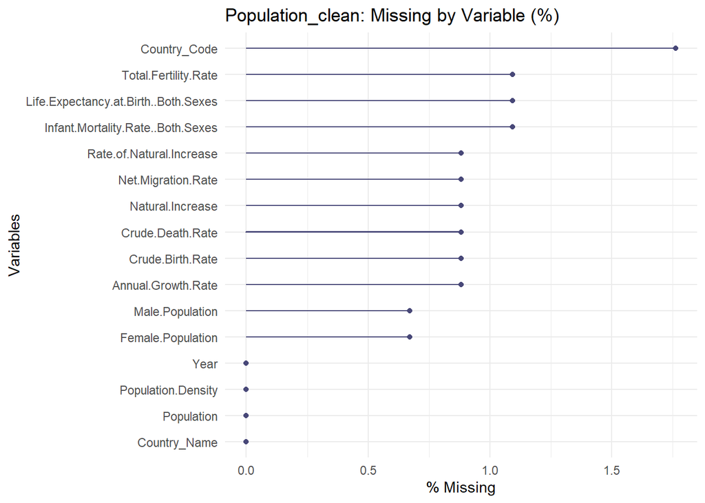

As depicted in the images, rows without country_code account for 3% in box_office_aggr table and 1.8% in population_clean table. And there are several variables with a few missing percent in population_clean table. All rows with NA in the two tables were removed. The result shows more than 95% rows were left.

In gdp_long table, time-series based imputation was applied to handle missing values of gdp_usd. Specifically, linear interpolation was used within each country across years, while for trailing missing values, last observation carried forward was applied. At last, rows which were still NA after interpolation were removed(account for less than 2.5%).

```
## Box Office : 96.71 %left
##  GDP : 97.73 %left
##  Population : 96.72 %left
```

## 4.4 Establishing a panel

Since all data was cleaned, a comprehensive panel was generated by merging tabels based on country code and year.

```
## # A tibble: 20 × 31
##    Country_Code  Year n_films worldwide_usd_sum domestic_usd_sum domestic_share
##    <chr>        <int>   <int>             <dbl>            <dbl>          <dbl>
##  1 ARE           2009       1          28972508         20919166         0.722
##  2 ARE           2010       4         147123299         55384910         0.376
##  3 ARE           2011       2         353154979        245366209         0.695
##  4 ARE           2012       2         269400086         98186043         0.364
##  5 ARE           2013       1          57824674         42930462         0.742
##  6 ARE           2014       1          89078609         54240821         0.609
##  7 ARE           2017       3         524273643         62049989         0.118
##  8 ARE           2023       1           9387311          4813132         0.513
##  9 ARE           2024       1          15469415         10001000         0.647
## 10 ARG           2001       1           8772695           624757         0.0712
## 11 ARG           2002       1          12413888          1222889         0.0985
## 12 ARG           2004       1          57663224         16781387         0.291
## 13 ARG           2009       1          35079650          6391436         0.182
## 14 ARG           2014       1          31478893          3106530         0.0987
## 15 ARG           2016       1          52444295           568876         0.0108
## 16 ARG           2020       1           7627100                0         0
## 17 AUS           2000       2          46864130         30881051         0.659
## 18 AUS           2001       9         552863456        269636791         0.488
## 19 AUS           2002       7         331161187        171573012         0.518
## 20 AUS           2003       1          47488536         32551396         0.685
## # ℹ 25 more variables: Country_Name.x <chr>, Indicator.Name <chr>,
## #   Indicator.Code <chr>, gdp_usd <dbl>, Country_Name.y <chr>,
## #   Population <dbl>, Male.Population <dbl>, Female.Population <dbl>,
## #   Annual.Growth.Rate <dbl>, Rate.of.Natural.Increase <dbl>,
## #   Population.Density <dbl>, Natural.Increase <dbl>,
## #   Total.Fertility.Rate <dbl>, Crude.Birth.Rate <dbl>,
## #   Life.Expectancy.at.Birth..Both.Sexes <dbl>, …
```

# 5. Classification, Feature Engineering, and Feature Selection

## 5.1 Feature Engineering and Selection

In panel table, box_per_capita is chosen as response variable, since it could reflect the size of box office market across different countries more fairly. Then the median is used as the threshold to divide countries into High and Low categories, avoiding the influence of some extreme values on the results.

```
##
## High  Low
##  347  348
```

A subset of the most relevant features is selected for the classification task.Removed useless variables such as unique identifiers (Country_Code, Year) and redundant text columns (Country_Name). Features, related to economic development (gdp_usd, gdp_per_capita), population (Population), and social indicators (Life Expectancy), are kept for next step. Moreover, variables that may cause collinearity are discarded, for example, keeping only Population instead of Male.Population and Female.Population. Log-transformed variables (log_gdp, log_pop) are included to reduce skewness and stabilize variance. This generates a balanced feature set that combines economic, demographic, and social factors without redundancy.

```
## # A tibble: 10 × 9
##    gdp_usd gdp_per_capita Population Life.Expectancy.at.B…¹ Total.Fertility.Rate
##      <dbl>          <dbl>      <dbl>                  <dbl>                <dbl>
##  1 2.54e11         31564.    8032709                   77.3                 1.5
##  2 3.00e11         37426.    8020877                   77.4                 1.57
##  3 3.61e11         43462.    8302211                   77.6                 1.59
##  4 3.85e11         44688.    8606553                   77.8                 1.64
##  5 4.00e11         44812.    8930981                   77.9                 1.66
##  6 4.14e11         45156.    9170474                   78.1                 1.66
##  7 3.91e11         40921.    9543192                   78.6                 1.69
##  8 5.14e11         51550.    9973449                   79.8                 1.62
##  9 5.37e11         53535.   10032213                   79.9                 1.61
## 10 2.69e11          7120.   37739191                   74.7                 2.46
## # ℹ abbreviated name: ¹Life.Expectancy.at.Birth..Both.Sexes
## # ℹ 4 more variables: box_gdp_ratio <dbl>, log_gdp <dbl>, log_pop <dbl>,
## #   box_class <chr>
```

## 5.2 Classification Modelling

Training/Test Split: We used an 80/20 split to evaluate model performance on unseen data. Merge rare countries into “OTHER” (count < 3)

```
##
## High  Low
##  278  279
```

```
##
## High  Low
##   69   69
```

Two classification models are implemented: decision tree and logistic regression.

Decision Tree: The tree structure provides interpretable decision rules.

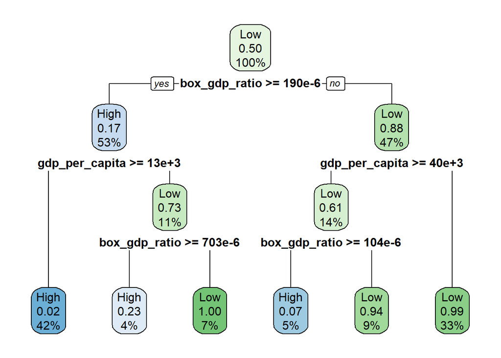

```
## Confusion Matrix and Statistics
##
##           Reference
## Prediction High Low
##       High   64   3
##       Low     5  66
##
##                Accuracy : 0.942
##                  95% CI : (0.889, 0.9746)
##     No Information Rate : 0.5
##     P-Value [Acc > NIR] : <2e-16
##
##                   Kappa : 0.8841
##
##  Mcnemar's Test P-Value : 0.7237
##
##             Sensitivity : 0.9275
##             Specificity : 0.9565
##          Pos Pred Value : 0.9552
##          Neg Pred Value : 0.9296
##              Prevalence : 0.5000
##          Detection Rate : 0.4638
##    Detection Prevalence : 0.4855
##       Balanced Accuracy : 0.9420
##
##        'Positive' Class : High
##
```

The decision tree model shows that box_office-GDP ratio and GDP per capita are the most influential features in distinguishing between High and Low categories. Countries with higher box office-GDP ratio and higher GDP per capita tend to be classified as High.

The confusion matrix indicates that the model’s performance has an overall accuracy of 94.2% and a Kappa value of 0.88, suggesting a relatively strong stability. Both sensitivity (92.8%) and specificity (95.7%) are high, meaning the model effectively identifies both High and Low cases. This means that the decision tree provides a robust and well-generalized classifier for this dataset.

Logistic Regression: A linear model suitable for binary classification.

```
## Confusion Matrix and Statistics
##
##           Reference
## Prediction High Low
##       High   66   1
##       Low     3  68
##
##                Accuracy : 0.971
##                  95% CI : (0.9274, 0.992)
##     No Information Rate : 0.5
##     P-Value [Acc > NIR] : <2e-16
##
##                   Kappa : 0.942
##
##  Mcnemar's Test P-Value : 0.6171
##
##             Sensitivity : 0.9565
##             Specificity : 0.9855
##          Pos Pred Value : 0.9851
##          Neg Pred Value : 0.9577
##              Prevalence : 0.5000
##          Detection Rate : 0.4783
##    Detection Prevalence : 0.4855
##       Balanced Accuracy : 0.9710
##
##        'Positive' Class : High
##
```

According to the results, the logistic regression model achieved a high performance, with an accuracy of 97.1% and a Kappa of 0.94, indicating excellent agreement beyond chance. Sensitivity (95.7%) and specificity (98.6%) are both high, showing that the model is effective at detecting both High and Low classes, as well as a very good precision value (above 95%). Overall, the logistic regression classifier provides a highly reliable model for distinguishing between High and Low cases in this dataset.

Model performance was evaluated using confusion matrices and ROC curves. Thus, it is more visual to compare accuracy and the trade-off between true positive and false positive rates.

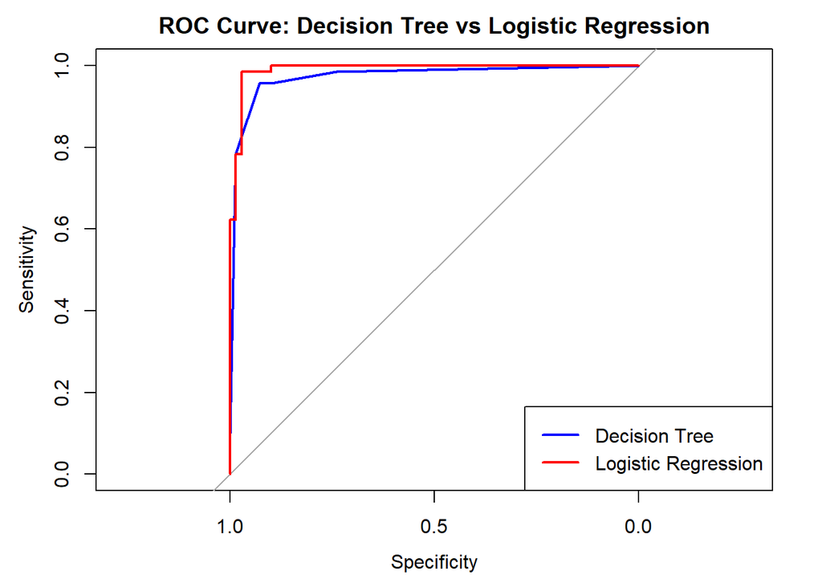

The ROC curves show that both the decision tree and logistic regression models, with lines close to the top-left corner, perform very well in this dataset. Logistic regression (red) is slightly ahead overall, reaching higher sensitivity at most points. The decision tree (blue) also works well, but logistic regression gives a more steady performance.

# 6. Conclusion

In this project, I had a comprehensive practice of exploratory analysis, data cleaning, and classification modelling. After constructing a cleaned panel dataset from given datasets, box office per capita was selected as the target variable for classification. Two models were tested: a decision tree and logistic regression. Both methods achieved strong results, with accuracies above 94%. The decision tree provided clear and interpretable rules, while logistic regression delivered slightly better performance overall, reaching 97% accuracy and higher ROC values. These findings suggest that economic and demographic indicators are effectively positive predictors of box office scale across countries. Additionally, logistic regression performed better than decision tree for this dataset.